# Reproducible Research: Peer Assessment 1

## Loading and preprocessing the data

read the CSV file, put in a data frame called activity, generte some information about our dataframe like dimension and data!!

```r
activity <- read.csv(unz("activity.zip", "activity.csv"), header=T, sep=",")
dim(activity)
```

```
## [1] 17568     3
```

```r
head(activity,n=5)
```

```
##   steps       date interval
## 1    NA 2012-10-01        0
## 2    NA 2012-10-01        5
## 3    NA 2012-10-01       10
## 4    NA 2012-10-01       15
## 5    NA 2012-10-01       20
```

## What is mean total number of steps taken per day?

first change the class of variable date (factor at first) to Date, second melt steps by date and interval to get list of steps for each day, then calculate total steps at each day:

```r
activity$date<-as.Date(activity$date)
stepsdata <- melt(activity, id.vars=c("date","interval"), na.rm = TRUE)
steps_day <- dcast(stepsdata, date~variable, sum)
```

the total number of steps taken per day:

```r
dim(steps_day)
```

```
## [1] 53  2
```

```r
head(steps_day,n=10)
```

```
##          date steps
## 1  2012-10-02   126
## 2  2012-10-03 11352
## 3  2012-10-04 12116
## 4  2012-10-05 13294
## 5  2012-10-06 15420
## 6  2012-10-07 11015
## 7  2012-10-09 12811
## 8  2012-10-10  9900
## 9  2012-10-11 10304
## 10 2012-10-12 17382
```

histogram of the total number of steps taken each day:

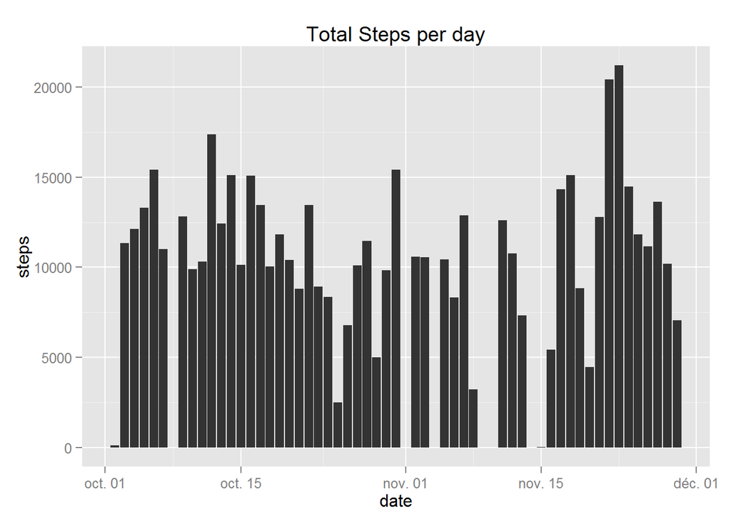

```r
qplot(date,steps, data=steps_day, xlab = deparse(substitute(date)),geom="histogram",stat="identity",main ="Total Steps per day")
```

Mean and Median of the total number of steps taken per day:

```r
mean(steps_day$steps)
```

```
## [1] 10766.19
```

```r
median(steps_day$steps)
```

```
## [1] 10765
```

## What is the average daily activity pattern?

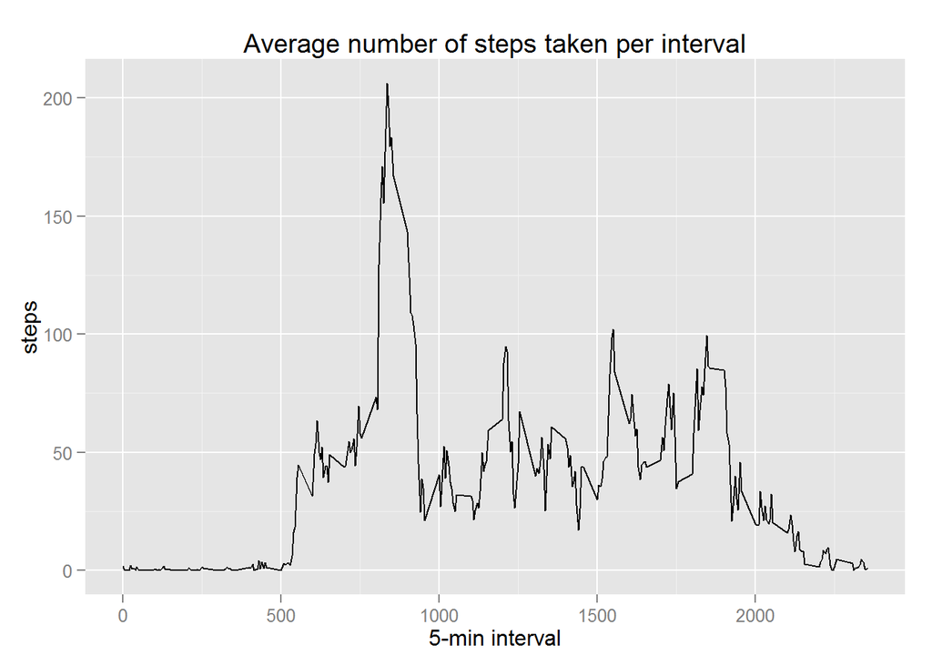

```r
steps_interval <- dcast(stepsdata, interval~variable, mean)
qplot(interval,steps, data=steps_interval,geom="line",stat="identity",main ="Average number of steps taken per interval", xlab ="5-min interval")
```

In 5-minute interval, the maximum number of steps is:

```r
steps_interval_sum <- dcast(stepsdata, interval~variable, sum)
steps_interval_sum[which.max(steps_interval_sum$steps),]
```

```
##     interval steps
## 104      835 10927
```

## Imputing missing values

1- the total number of missing values in the dataset:

```r
activity_NA<-activity[!complete.cases(activity),]
dim(activity_NA)[1]
```

```
## [1] 2304
```

2- strategy for filling in all of the missing values in the dataset:

```r
activity_mutNA <-mutate(activity_NA,steps=round(mean(steps_interval$steps)))
```

3- original dataset with the missing data filled in

```r
activity_noNA<-activity[complete.cases(activity),]
activity_filledNA<-rbind(activity_mutNA,activity_noNA)
head(activity_filledNA,n=10)
```

```
##    steps       date interval
## 1     37 2012-10-01        0
## 2     37 2012-10-01        5
## 3     37 2012-10-01       10
## 4     37 2012-10-01       15
## 5     37 2012-10-01       20
## 6     37 2012-10-01       25
## 7     37 2012-10-01       30
## 8     37 2012-10-01       35
## 9     37 2012-10-01       40
## 10    37 2012-10-01       45
```

4- histogram of the total number of steps taken each day:

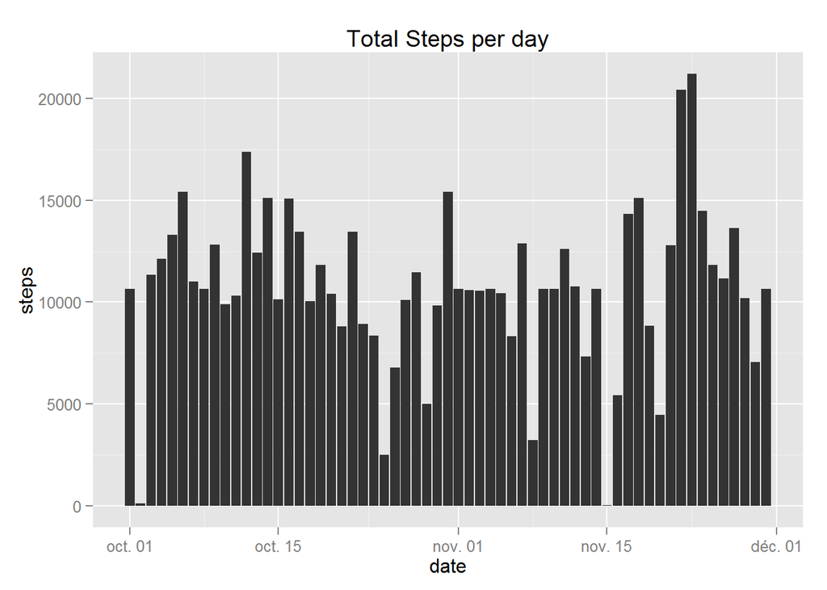

```r
stepsdata_filledNA <- melt(activity_filledNA, id.vars=c("date","interval"), na.rm = TRUE)
steps_day_filledNA <- dcast(stepsdata_filledNA, date~variable, sum)
qplot(date,steps, data=steps_day_filledNA, xlab = deparse(substitute(date)),geom="histogram",stat="identity",main ="Total Steps per day")
```

mean and median of steps taken per day:

```r
mean(steps_day_filledNA$steps)
```

```
## [1] 10751.74
```

```r
median(steps_day_filledNA$steps)
```

```
## [1] 10656
```

## Are there differences in activity patterns between weekdays and weekends?

```r
steps_week<-activity_filledNA
steps_week$date<-weekdays(steps_week$date)
#considere my french language
steps_week2 <- mutate(steps_week, factor = ifelse(date == "samedi" | date == "dimanche", "Weekend", "Weekday"))
```

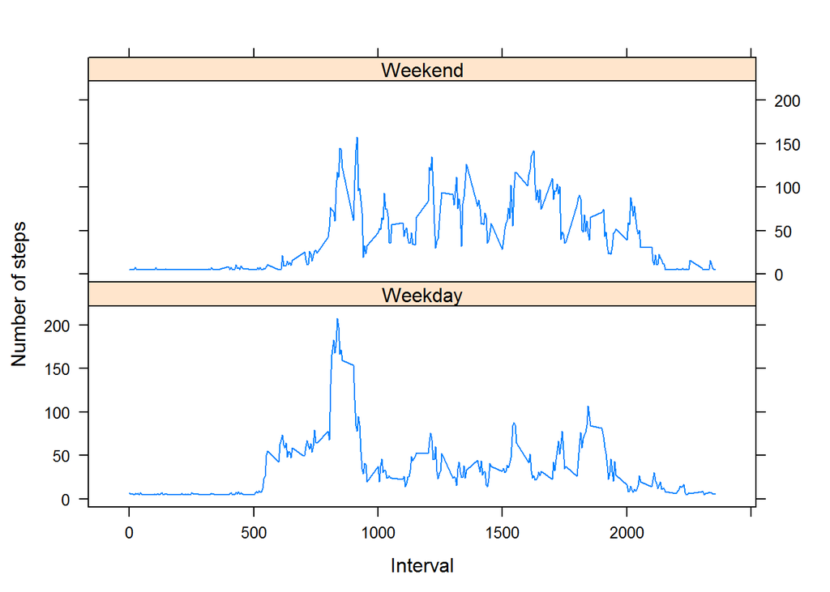

```r
datafinal<- aggregate(steps ~ interval + factor, data = steps_week2, mean)
xyplot(steps ~ interval|factor, datafinal, type = "l", layout = c(1, 2),
       xlab = "Interval", ylab = "Number of steps")
```